# subtask 3

Nzambuli Daniel

2024-06-10

# Question

A manager of a national park collected data on the number of visitors (in thousands) who visited the park in each quarter of 2021 and 2022. The data includes:

| season | Seasonal index | 2021 | 2022 |
| --- | --- | --- | --- |
| summer | 162 | 51 | 54 |
| moonsoon | 62 | 28 | 32 |
| winter | 87 | 41 | 45 |
| spring | 89 | 36 | 43 |

## Tasks:

### 1. Calculate the deseasonalized values for each quarter.

$$seasonal\ index = \frac{real\ value}{cMA} * 100$$

```r
data = data.frame(season = c("summer", "monsoon", "winter", "spring"),
                  visit_2021 = c(51, 28, 41, 36),
                  visit_2022 = c(54, 32, 45, 43),
                  seas_ind = c(162, 62, 87, 89))

library(tidyr)
data_long = pivot_longer(data, cols = c(visit_2021, visit_2022) , values_to = "visitors", names_to = "year")
data_long
```

```
## # A tibble: 8 × 4
##   season  seas_ind year       visitors
##   <chr>      <dbl> <chr>         <dbl>
## 1 summer       162 visit_2021       51
## 2 summer       162 visit_2022       54
## 3 monsoon       62 visit_2021       28
## 4 monsoon       62 visit_2022       32
## 5 winter        87 visit_2021       41
## 6 winter        87 visit_2022       45
## 7 spring        89 visit_2021       36
## 8 spring        89 visit_2022       43
```

```r
library(dplyr)
data_long = data_long %>%
  mutate(year = sub("visit_", "", year))

data_long
```

```
## # A tibble: 8 × 4
##   season  seas_ind year  visitors
##   <chr>      <dbl> <chr>    <dbl>
## 1 summer       162 2021        51
## 2 summer       162 2022        54
## 3 monsoon       62 2021        28
## 4 monsoon       62 2022        32
## 5 winter        87 2021        41
## 6 winter        87 2022        45
## 7 spring        89 2021        36
## 8 spring        89 2022        43
```

#### Deaseasoned data

```r
data_long$desnd_data = data_long$visitors/data_long$seas_ind * 100

data_long
```

```
## # A tibble: 8 × 5
##   season  seas_ind year  visitors desnd_data
##   <chr>      <dbl> <chr>    <dbl>      <dbl>
## 1 summer       162 2021        51       31.5
## 2 summer       162 2022        54       33.3
## 3 monsoon       62 2021        28       45.2
## 4 monsoon       62 2022        32       51.6
## 5 winter        87 2021        41       47.1
## 6 winter        87 2022        45       51.7
## 7 spring        89 2021        36       40.4
## 8 spring        89 2022        43       48.3
```

#### Order by Year

```r
data_long = data_long %>% arrange(year)

data_long
```

```
## # A tibble: 8 × 5
##   season  seas_ind year  visitors desnd_data
##   <chr>      <dbl> <chr>    <dbl>      <dbl>
## 1 summer       162 2021        51       31.5
## 2 monsoon       62 2021        28       45.2
## 3 winter        87 2021        41       47.1
## 4 spring        89 2021        36       40.4
## 5 summer       162 2022        54       33.3
## 6 monsoon       62 2022        32       51.6
## 7 winter        87 2022        45       51.7
## 8 spring        89 2022        43       48.3
```

### 2. Compute the trend values for the deseasonalized data.

$$\sum Y_{t} = n \beta_0 + \beta_1 \sum x_t\\
\sum x_t y_t = \beta_0\sum x_t + \beta_1 \sum x_t^2$$

$t = seq\{1, n\}$

$x_t = 2 ( t - median(t))$

```r
data_long$t = seq(1, nrow(data_long))
med_t = median(data_long$t)
data_long$x_t = 2*(data_long$t - med_t)
data_long$des_x_t = data_long$desnd_data * data_long$x_t
data_long
```

```
## # A tibble: 8 × 8
##   season  seas_ind year  visitors desnd_data     t   x_t des_x_t
##   <chr>      <dbl> <chr>    <dbl>      <dbl> <int> <dbl>   <dbl>
## 1 summer       162 2021        51       31.5     1    -7  -220.
## 2 monsoon       62 2021        28       45.2     2    -5  -226.
## 3 winter        87 2021        41       47.1     3    -3  -141.
## 4 spring        89 2021        36       40.4     4    -1   -40.4
## 5 summer       162 2022        54       33.3     5     1    33.3
## 6 monsoon       62 2022        32       51.6     6     3   155.
## 7 winter        87 2022        45       51.7     7     5   259.
## 8 spring        89 2022        43       48.3     8     7   338.
```

$$\frac{\sum y_t}{n} = \beta_0\\
\sum x_t y_t = \beta_1 \sum x_t^2$$

```r
data_long$x_t_sqrd = data_long$x_t ^ 2
data_long
```

```
## # A tibble: 8 × 9
##   season  seas_ind year  visitors desnd_data     t   x_t des_x_t x_t_sqrd
##   <chr>      <dbl> <chr>    <dbl>      <dbl> <int> <dbl>   <dbl>    <dbl>
## 1 summer       162 2021        51       31.5     1    -7  -220.        49
## 2 monsoon       62 2021        28       45.2     2    -5  -226.        25
## 3 winter        87 2021        41       47.1     3    -3  -141.         9
## 4 spring        89 2021        36       40.4     4    -1   -40.4        1
## 5 summer       162 2022        54       33.3     5     1    33.3        1
## 6 monsoon       62 2022        32       51.6     6     3   155.         9
## 7 winter        87 2022        45       51.7     7     5   259.        25
## 8 spring        89 2022        43       48.3     8     7   338.        49
```

#### Find $\beta_0$ and $\beta_1$

```r
n = nrow(data_long)
beta_0 = sum(data_long$desnd_data) / n
beta_1 = sum(data_long$des_x_t) / sum(data_long$x_t_sqrd)

cat("beta 0 and beta 1:\n",beta_0, "\t", beta_1 )
```

```
## beta 0 and beta 1:
##  43.65045     0.9344608
```

#### trend values

```r
data_long$trend = beta_0 + beta_1 * data_long$x_t

data_long
```

```
## # A tibble: 8 × 10
##   season  seas_ind year  visitors desnd_data     t   x_t des_x_t x_t_sqrd trend
##   <chr>      <dbl> <chr>    <dbl>      <dbl> <int> <dbl>   <dbl>    <dbl> <dbl>
## 1 summer       162 2021        51       31.5     1    -7  -220.        49  37.1
## 2 monsoon       62 2021        28       45.2     2    -5  -226.        25  39.0
## 3 winter        87 2021        41       47.1     3    -3  -141.         9  40.8
## 4 spring        89 2021        36       40.4     4    -1   -40.4        1  42.7
## 5 summer       162 2022        54       33.3     5     1    33.3        1  44.6
## 6 monsoon       62 2022        32       51.6     6     3   155.         9  46.5
## 7 winter        87 2022        45       51.7     7     5   259.        25  48.3
## 8 spring        89 2022        43       48.3     8     7   338.        49  50.2
```

### 3. Plot the quarterly number of visitors for 2021 and 2022, along with the deseasonalized values and trend values on the same graph.

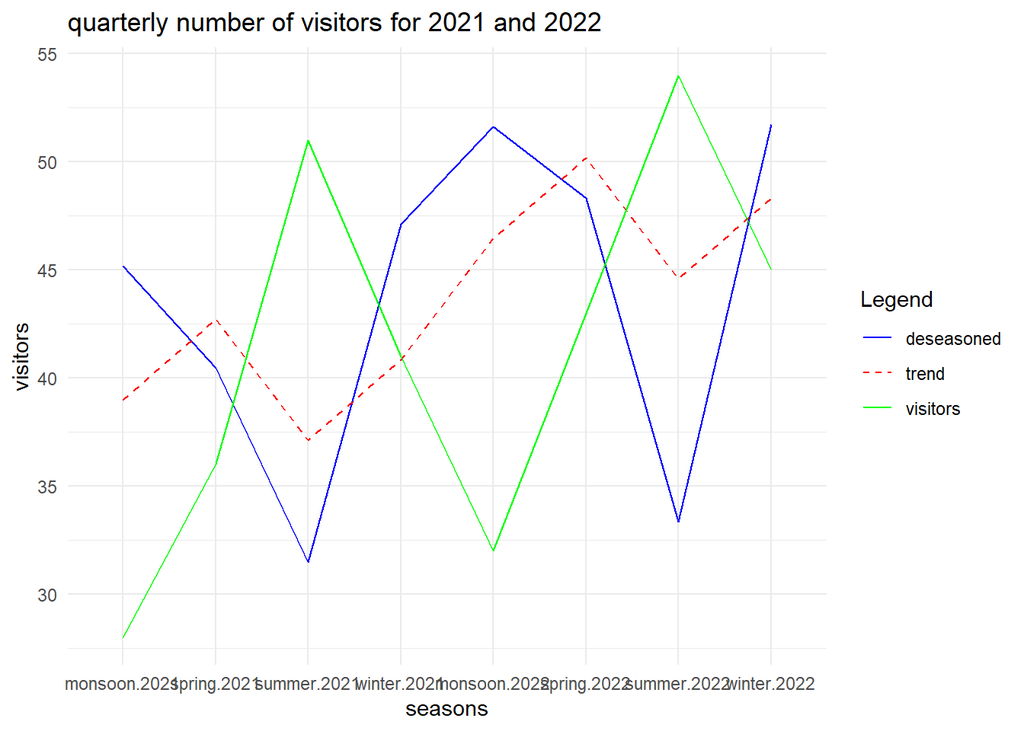

```r
data_long$x = rep(seq(1,4), 2)

library(ggplot2)

ggplot(data_long, aes(x = interaction(season, year), group = 1))+
  geom_line(aes(y = desnd_data, color = "deseasoned"))+
  geom_line(aes(y = trend, color = "trend"), linetype = "dashed")+
  geom_line(aes(y = visitors, color = "visitors"))+
  labs(
    title = "quarterly number of visitors for 2021 and 2022",
    y = "visitors",
    x = "seasons"
  )+
  scale_color_manual(name = "Legend", values = c("deseasoned" = "blue", "trend" = "red","visitors" = "green")) +
  theme_minimal()
```

#### Trend lines are smooth lines because they are generated by

$$trend = 43.654 + 0.93 X_t$$

This is the equation of a straight line with an intercept at `43.654`

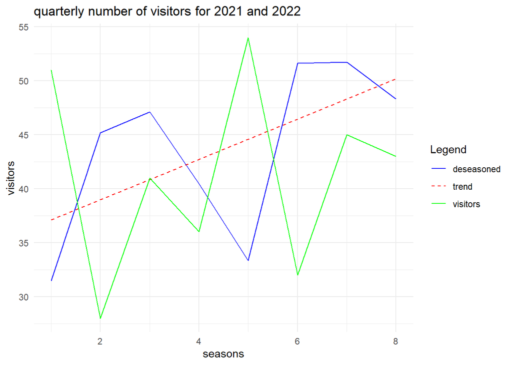

```r
ggplot(data_long, aes(x = t, group = 1))+
  geom_line(aes(y = desnd_data, color = "deseasoned"))+
  geom_line(aes(y = trend, color = "trend"), linetype = "dashed")+
  geom_line(aes(y = visitors, color = "visitors"))+
  labs(
    title = "quarterly number of visitors for 2021 and 2022",
    y = "visitors",
    x = "seasons"
  )+
  scale_color_manual(name = "Legend", values = c("deseasoned" = "blue", "trend" = "red","visitors" = "green")) +
  theme_minimal()
```

**Interpretation**

1. Summer has the highest number of visitors with monsoon having the least number of visitors
2. The deseasonalized graph represents data without the effect periodic fluctuation like holidays and the prevailing weather.
   1. The data in the second plot is 1 -> summer , 2 -> monsoon, 3 -> winter, 4 -> spring
   2. The **summer** predictions tend to be **lower** than anticipated indicating an overall increase in the number of visitors than expected
   3. The **winter and monsoon** have the highest predictions than the actual visitors indicating less than predicted visitors.
3. The `overall` trend is that the number of visitors are increasing as time goes by. This can be augmented by presenting sites that visitors can go to during winter and monsoon season to help reflect the predicted values and increase the total visitors over time

The initial trend-line may not be accurate as the analysis starts in summer however the graph indicates the monsoon season is the initial season for the region.

The graph may however indicate when interventions may be implemented to facilitate maximum visitation.